# Estudis d'Informàtica, Multimedia i Telecomunicacions

# Mineria de dades: PAC2 - Mètodes no supervisats

Autor: Jordi Puig Ovejero

Abril 2020

# 1 Presentació

Aquesta Prova d’Avaluació Continuada cobreix principalment els mòduls 5 i 6 (Mètodes d’agregació i algoritmes d’associació) del programa de l’assignatura

El primer que fem es carregar les llibreries que es necessiten

```r
library(cluster)
library(dplyr)
library(class)
library(purrr)
library(ggplot2)
library(factoextra)
library(mclust)
library(fpc)
library(arules)
```

# 2 Exercici 1.1

## 2.1 Estudi previ de les dades

L’exercici parteix d’una mostra de dades de llavors de blat. Aquesta mostra conté 210 instàncias de 3 varietats diferents de blat: Kama, Rosa i Canadian, 70 elements cadascuna, seleccionades aleatòriament per l’experiment. Es va detectar una visualització d’alta qualitat de l’estructura del nucli intern (kernel) mitjançant una tècnica de raigs X. És no destructiu i considerablement més barat que altres tècniques d’imatge més sofisticades com la microscòpia d’escaneig o la tecnologia làser. Les imatges es van gravar en plaques KODAK de raigs X de 13x18 cm. Els estudis van ser realitzats a l’Institut d’Agrofísica de l’Acadèmia de Ciències Polonesa de Lublin.

El conjunt de dades es pot utilitzar per a tasques tant de classificació com anàlisi de clústers.

```r
seed_data<-read.csv('seeds.csv',stringsAsFactors = FALSE)
attach(seed_data)
summary(seed_data)
```

```
##       area         perimeter      compactness      lengthKernel
##  Min.   :10.59   Min.   :12.41   Min.   :0.8081   Min.   :4.899
##  1st Qu.:12.27   1st Qu.:13.45   1st Qu.:0.8569   1st Qu.:5.262
##  Median :14.36   Median :14.32   Median :0.8734   Median :5.524
##  Mean   :14.85   Mean   :14.56   Mean   :0.8710   Mean   :5.629
##  3rd Qu.:17.30   3rd Qu.:15.71   3rd Qu.:0.8878   3rd Qu.:5.980
##  Max.   :21.18   Max.   :17.25   Max.   :0.9183   Max.   :6.675
##   widthKernel    asymmetryCoefficient lengthKernelGroove     class
##  Min.   :2.630   Min.   :0.7651       Min.   :4.519      Min.   :1
##  1st Qu.:2.944   1st Qu.:2.5615       1st Qu.:5.045      1st Qu.:1
##  Median :3.237   Median :3.5990       Median :5.223      Median :2
##  Mean   :3.259   Mean   :3.7002       Mean   :5.408      Mean   :2
##  3rd Qu.:3.562   3rd Qu.:4.7687       3rd Qu.:5.877      3rd Qu.:3
##  Max.   :4.033   Max.   :8.4560       Max.   :6.550      Max.   :3
```

Anem a veure si tenim valors null, per tracatar-los:

```r
colSums(is.na(seed_data))
```

```
##                 area            perimeter          compactness
##                    0                    0                    0
##         lengthKernel          widthKernel asymmetryCoefficient
##                    0                    0                    0
##   lengthKernelGroove                class
##                    0                    0
```

No tenim valors nulls.

Afegim una columna amb el noms de les llavors

```r
seed_data <- seed_data %>%
  mutate(classname = case_when(
    class == 1 ~ "Rosa",
    class == 2 ~ "Kama",
    class == 3 ~ "Canadian"
  ))
```

```r
str(seed_data)
```

```
## 'data.frame':    210 obs. of  9 variables:
##  $ area                : num  15.3 14.9 14.3 13.8 16.1 ...
##  $ perimeter           : num  14.8 14.6 14.1 13.9 15 ...
##  $ compactness         : num  0.871 0.881 0.905 0.895 0.903 ...
##  $ lengthKernel        : num  5.76 5.55 5.29 5.32 5.66 ...
##  $ widthKernel         : num  3.31 3.33 3.34 3.38 3.56 ...
##  $ asymmetryCoefficient: num  2.22 1.02 2.7 2.26 1.35 ...
##  $ lengthKernelGroove  : num  5.22 4.96 4.83 4.8 5.17 ...
##  $ class               : int  1 1 1 1 1 1 1 1 1 1 ...
##  $ classname           : chr  "Rosa" "Rosa" "Rosa" "Rosa" ...
```

Per construir les dades, s’han mesurat 7 paràmetres geomètrics de grans de blat:

- 1. area A,
- 2. perimeter P,
- 3. compactness C = 4*pi*A/P^2,
- 4. length of kernel (longitud del nucli),
- 5. width of kernel (amplada del nucli),
- 6. asymmetry coefficient (coeficient d’asimetria),
- 7. length of kernel groove (longitud del solc del nucli),
- 8. class (classe a la pertanyen, 1, 2 o 3)
- 9. classname (nom de la classe a la pertanyen, Rosa, Kama o Canadian)

La base de dades está ja classificada i el que farem serà treure la columna de class que identifica als tipus de llavors per a poder fer l’exercici. Ens quedem únicament amb les columnes que defineixen a cada llavor:

```r
x <- seed_data[,1:7]
```

## 2.2 Execució i estudi del algoritme k-means (o centroides)

Aquest algoritme primerament fixa un nombre de clusters (o centres de clusters) i a partir d’aquest número construeix els grups. Per a executar el mètode de k-means o centroides partim de la base que no coneixem el número òptim de clústers. Provarem amb varis centres (del 2 al 10) per veure quina aproximació és millor.

Per a cada iteració obtenim:

- generació dels clusters a partir del mètode d’agregació k-means
- silhouette - per avaluar la qualitat dels clusters trobats
- emmagatzem la silueta mitja de la prova iésima al array ‘results’

```r
d <- daisy(x)
results <- rep(0, 10)
for (i in c(2,3,4,5,6,7,8,9,10))
{
  fit           <- kmeans(x, i)
  y_cluster     <- fit$cluster
  sk            <- silhouette(y_cluster, d)
  results[i] <- mean(sk[,3])
}
```

Mostrem en una gràfica els valors de la silueta mitja de cada prova per comprovar quin nombre de clusters és el millor. Com mes alt es el valor de la silueta, millor

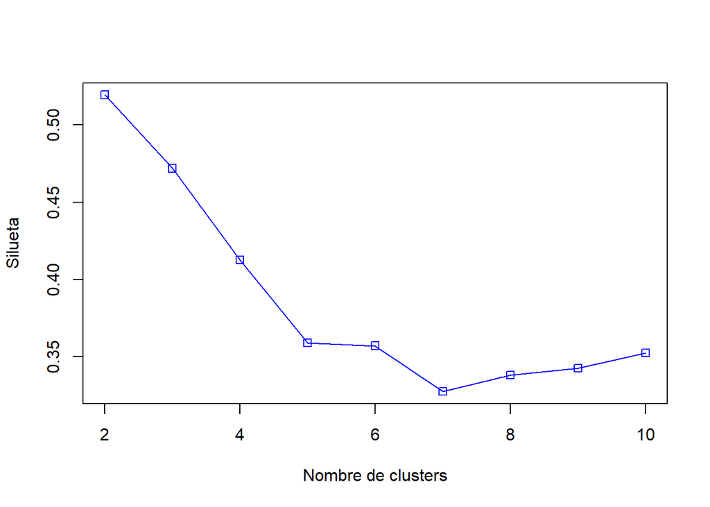

```r
plot(2:10,results[2:10],type="o",col="blue",pch=0,xlab="Nombre de clusters",ylab="Silueta")
```

El millor valor obtingut es de dos clusters encara que sabem per la mostra agafada que l’original té 3 classes.

Un altre forma d’evaluar quin és el millor nombre de clústers és considerar el millor model amb aquestes condicions:

- Ofereix la menor suma dels quadrats de les distàncies dels punts de cada grup amb respecte al seu centre (withinss). *Els elements dels grups estan junts.*
- La separació més gran entre centres de grups (betweenss). *Els grups están separats.*

És una idea conceptualment similar a la silueta. Una manera comú de fer la selecció del nombre de clústers consisteix a aplicar el mètode elbow (colze). És fa una selecció del nombre de clústers a partir de la inspecció de la gràfica que s’obté l’iterar amb el mateix conjunt de dades per a distints valors del nombre de clústers. Es seleccionarà el valor que és troba en el colze de la corba.

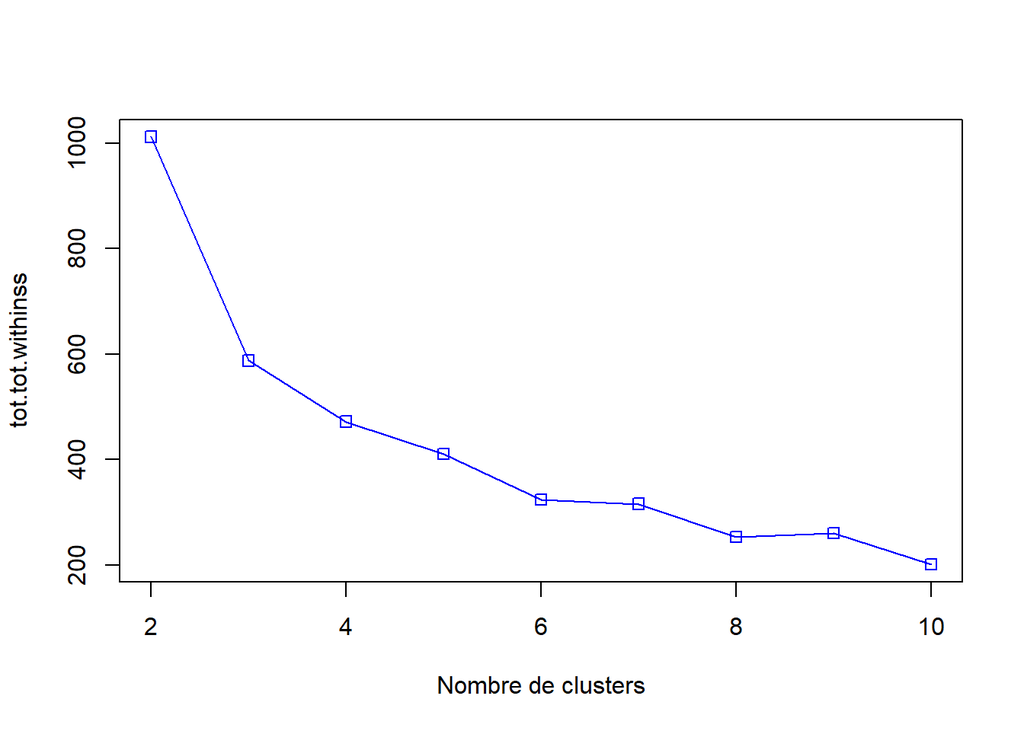

```r
resultados <- rep(0, 10)
for (i in c(2,3,4,5,6,7,8,9,10))
{
  fit           <- kmeans(x, i)
  resultados[i] <- fit$tot.withinss
}
plot(2:10,resultados[2:10],type="o",col="blue",pch=0,xlab="Nombre de clusters",ylab="tot.tot.withinss")
```

A partir de la corba obtinguda podem veure com a mesura que s’augmenta la quantitat de centroides, el valor de “tot.tot.withinss” disminueix, ja que la separació entre elements dels clusters es inferior. La idea és trobar un “colze”. *El colze és troba on ja no es produeixen variacions importants a l’augmentar ‘Nombre de clusters’.* El valor és el 3 (seria el correcte).

Una altra aproximació similar, on només mostrem la distància entre els quadrats dels elements dels clusters (withinss):

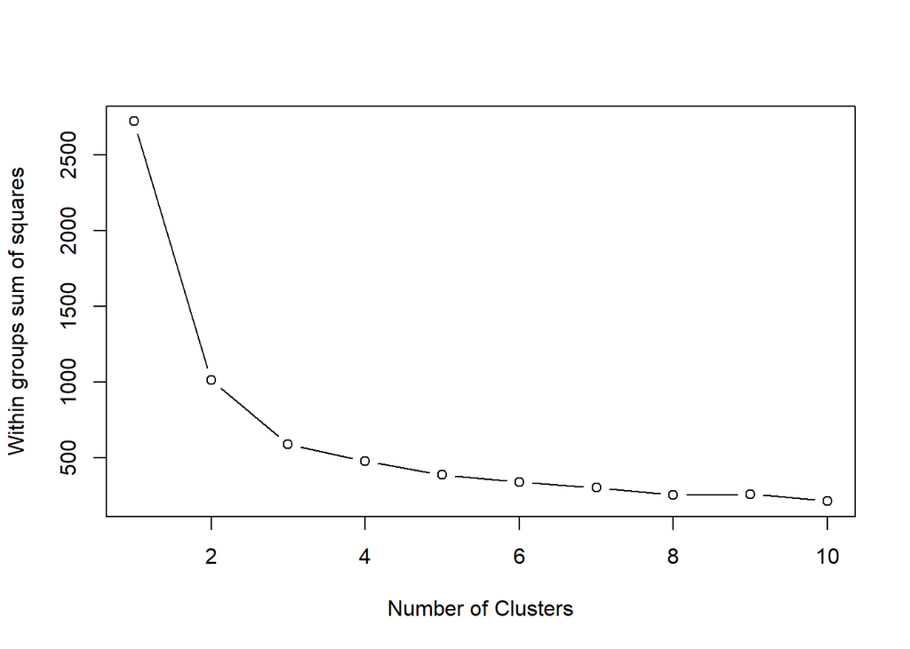

```r
# agafem la primera iteració
wss <- sum(kmeans(x,centers=1)$withinss)

# agafem iteracions del 2 al 10
for (i in 2:10) wss[i] <- sum(kmeans(x,centers=i)$withinss)

# pintem els 10 withinss.
plot(1:10, wss, type="b", xlab="Number of Clusters",ylab="Within groups sum of squares")
```

Agafaríem també l’opció 3, ja que és el nombre més gran de clusters on la distancia entre els elements del clusters és més petita. A partir del 3 s’estabilitza moltíssim i quasi no hi ha variació entre la distancia dels elements dels grups.

També es pot fer servir la funció kmeansruns del paquet fpc que executarà l’algoritme kmeans com un conjunt de valors i selecciona el valor del nombre de clústers que millor funcioni d’acord amb dos criteris: la silueta mitja (asw) i Calinski-Harabasz (“ch”).

```r
fit_ch  <- kmeansruns(x, krange = 1:10, criterion = "ch")
fit_asw <- kmeansruns(x, krange = 1:10, criterion = "asw")
```

Podem comprovar el valor amb el qual s’ha obtingut el millor resultat i també mostrar el resultat obtingut per a tots els valors de k usant tots dos criteris

```r
fit_ch$bestk
```

```
## [1] 3
```

```r
fit_asw$bestk
```

```
## [1] 2
```

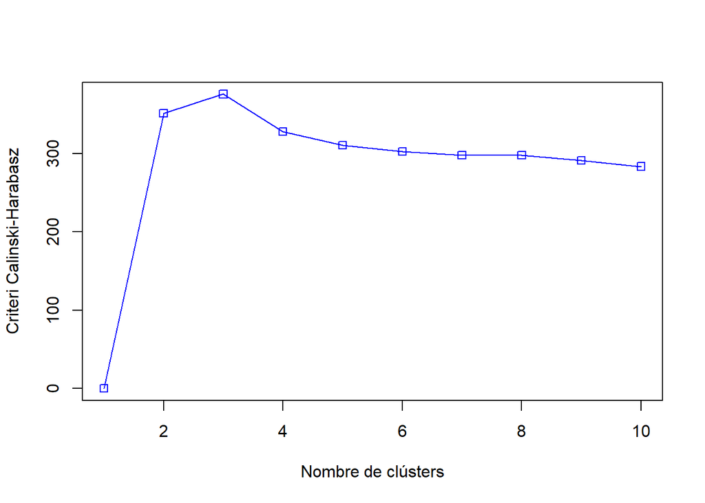

```r
plot(1:10,fit_ch$crit,type="o",col="blue",pch=0,xlab="Nombre de clústers",ylab="Criteri Calinski-Harabasz")
```

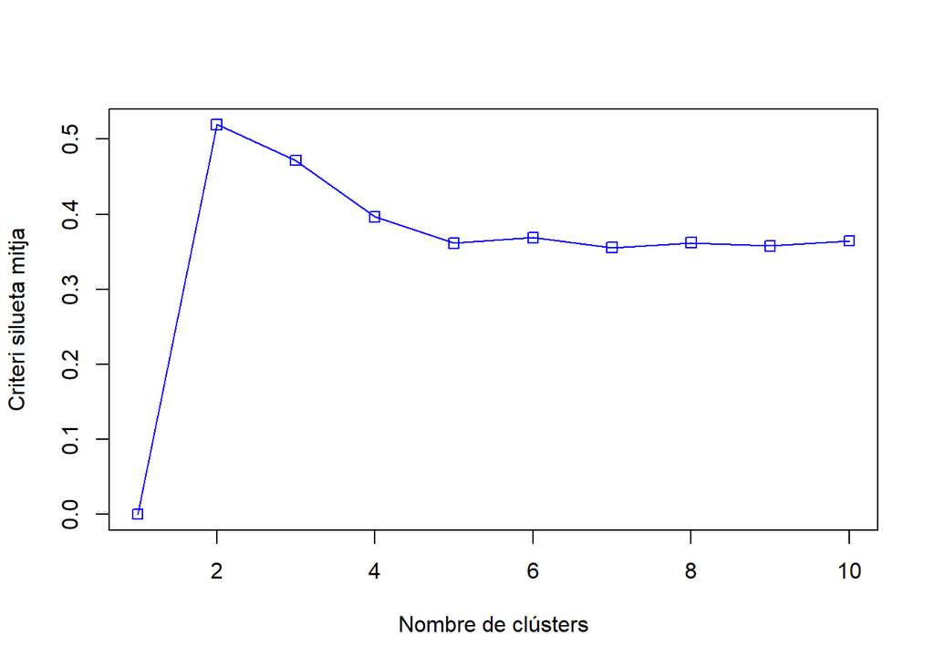

```r
plot(1:10,fit_asw$crit,type="o",col="blue",pch=0,xlab="Nombre de clústers",ylab="Criteri silueta mitja")
```

Els resultats son molt semblants als que hem obntingut anteriorment. Amb el criteri de la silueta mitja s’obtenen entre dos i tres clústers i amb el Calinski-Harabasz s’obtenen 3.

Anem a realitzar comparacions visuals amb el nombre de clusters que sabem hi han (3 Clusters)

```r
# realitzem una divisió en 3 clusters
seed3clusters <- kmeans(x, 3)
```

Primer visualitzarem els elements amb 3 clusters:

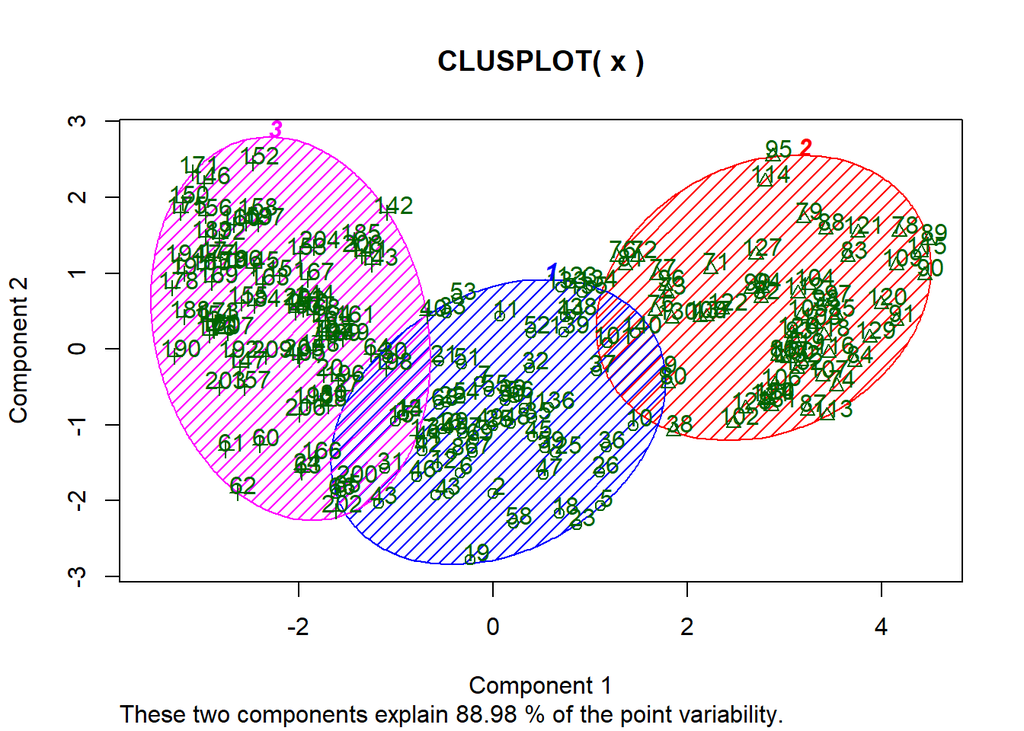

```r
clusplot(x, seed3clusters$cluster, color=TRUE, shade=TRUE, labels=2, lines=0)
```

```r
# realitzem una divisió en 2 clusters
seed2clusters <- kmeans(x, 2)
```

Ara visualitzem amb dos clusters:

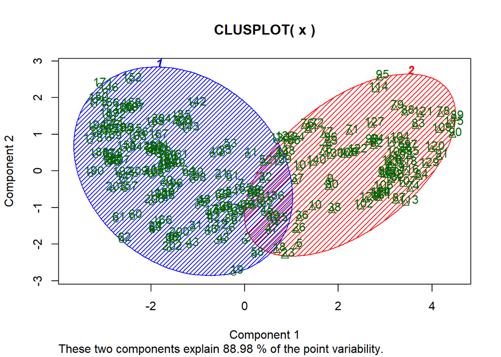

```r
clusplot(x, seed2clusters$cluster, color=TRUE, shade=TRUE, labels=2, lines=0)
```

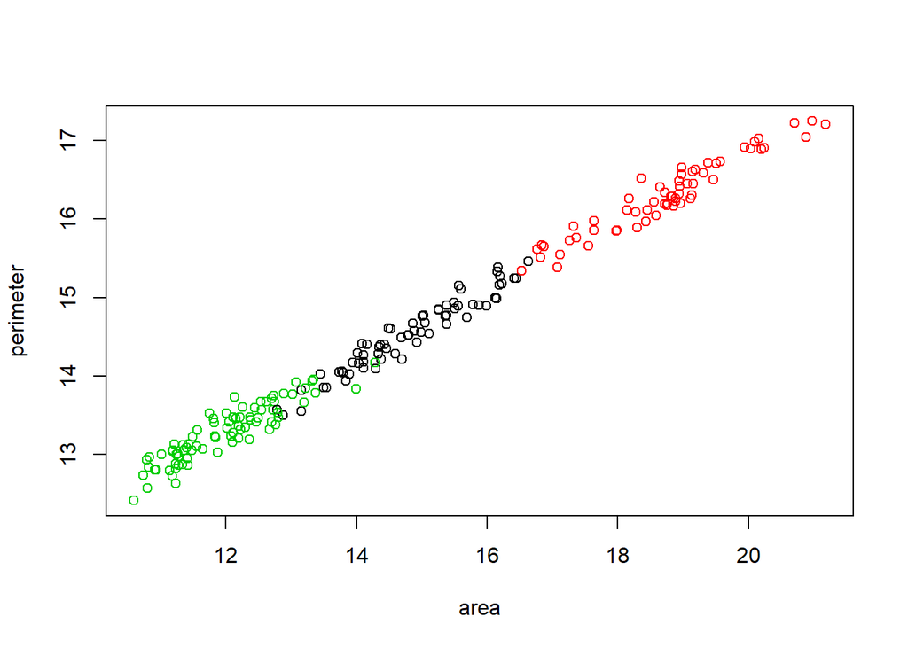

```r
# veiem visualment la relació 'area' i 'perimeter' entre el clusters realitzats i les class que sabem que existeixen
plot(x[c(1,2)], col=seed3clusters$cluster)
```